# Die Meistersinger von Nürnberg

Oper in drei Aufzügen (1868)

Musik und Text von Richard Wagner

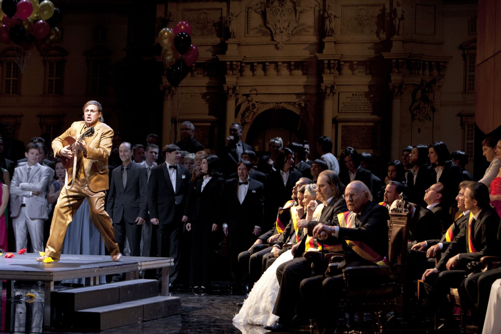

Als Richard Wagner um die Mitte der 1840er Jahre die ersten Ideen zu den Meistersingern von Nürnberg entwickelte, hatte er noch keineswegs im Sinn, eine monumentale Festoper zu schreiben. Eine Komödie von leichter Hand, ein heiter-humoristisches Satyrspiel sollte dieses Werk werden, seinem Tannhäuser an die Seite zu stellen, da hier wie dort Reflexionen über Kunst und Künstler im Mittelpunkt stehen. Mehr als zwei Jahrzehnte später lag dann eine Partitur vor, die zu den umfangreichsten und vielschichtigsten des gesamten Repertoires zählt und zu durchaus kontroversen Diskussionen anregte.

Die Solisten und der Chor, vor allem aber das groß besetzte Orchester entfalten eine außergewöhnliche Klangpracht – zu spüren ist dies sogleich im Vorspiel zum ersten Aufzug mit seinem C-Dur-Glanz und seinen großen Aufschwüngen voller Kraft und Helligkeit, in besonderem Maße aber auch in der abschließenden Szene auf der „Festwiese“, in der buchstäblich alles aufgefahren wird, was auf einer Opernbühne überhaupt denkbar erscheint. Staunen macht aber nicht nur die schier überwältigende klangliche Präsenz, sondern auch das immens hohe kompositionstechnische Niveau, das Wagner hier ins Werk gesetzt hat und das sich in den lyrischen, verinnerlichten Passagen als ebenso eindrucksvoll erweist. Seit der triumphalen Münchner Uraufführung vom Juni 1868 gehören die „Meistersinger“ zu den festen Säulen des europäischen Musiktheaters – als ein Werk, das abseits des Bühnenalltags demonstriert, was der Oper (bzw. dem Musikdrama) möglich ist.